# bayesDREAM vignette: NTC (technical) fit for a CRISPRi screen

This vignette walks through the **first stage** of the bayesDREAM pipeline — `fit_ntc()` — on a simulated CRISPRi dataset that mirrors a typical real-world setup:

- **CRISPRi only** (single perturbation modality, single guide per cell)
- Only the **primary ('gene') modality** — no transcript/splicing/ATAC data
- **NTC (non-targeting control) cells** are present, required for `fit_ntc()`
- **No guide-level covariates** (`guide_covariates` is left empty)
- **Many technical batches** — this is the whole point of `fit_ntc()`: it learns a per-batch, per-gene correction (`alpha_y`) from the NTC cells so that batch effects don't get mistaken for perturbation effects downstream
- `cis_gene` is **not set at initialisation** — we run `fit_ntc()` once, across the whole transcriptome, and only commit to a specific cis gene afterwards via `add_cis_gene()` (not covered in this vignette — see the "Next steps" section at the end).

Run this file top to bottom as a script, or cell-by-cell in VS Code / Jupyter (the `# %%` markers define cells).

```python
import os

import numpy as np
import pandas as pd
import torch
import pyro
import matplotlib.pyplot as plt

deviceno = 0
device = torch.device(f'cuda:{deviceno}' if torch.cuda.is_available() else 'cpu')

from bayesDREAM import bayesDREAM
```

## Reproducibility

Fix every RNG bayesDREAM touches: numpy (data simulation + internal use), torch (model parameters), and pyro (SVI sampling).

```python
SEED = 20260730
rng = np.random.default_rng(SEED)
np.random.seed(SEED)
torch.manual_seed(SEED)
pyro.set_rng_seed(SEED)
```

## What `meta` needs to contain

`bayesDREAM(meta=..., counts=..., ...)` validates `meta` up front. In **single-guide mode** (one guide per cell — the CRISPRi case here, as opposed to high-MOI mode where `guide_assignment`/`guide_meta` are passed instead), `meta` must have one row per cell and these columns:

| column | meaning |
| --- | --- |
| `cell` | cell barcode/ID — must match `counts.columns` 1:1 |
| `guide` | guide identifier (any string, unique per guide) |
| `target` | gene the guide targets; **NTC cells must use the literal string `"ntc"`** (lowercase) — `fit_ntc()`/init raise an error if no `"ntc"` cells are found, unless `require_ntc=False` |
| `sum_factor` | per-cell size factor, strictly > 0 (e.g. from `scran::calculateSumFactors`, as in `run_pipeline/prepare_inputs.py`) |

Plus, for every technical covariate you plan to correct for (batch, lane, 10x chip, processing date, ...) — one column per covariate, e.g. `batch`. These are *not* required by `__init__` itself, but `set_technical_groups()` needs them before `fit_ntc()` can run.

We are **not** using `guide_covariates`/`guide_covariates_ntc` here (no per-guide covariate columns needed) — CRISPRi with a plain guide -> target mapping is the simplest case.

`counts` is a genes x cells `pd.DataFrame` (or ndarray/sparse matrix + `feature_meta`) for the **primary modality** (`modality_name='gene'` by default). `feature_meta` is optional gene annotation — recommended columns `gene`/`gene_name`/`gene_id`; if omitted, minimal metadata is built from `counts.index`.

## Simulate a CRISPRi dataset

- `N_BACKGROUND_GENES` genes with no guides targeting them ("trans" candidates) plus 3 named genes (`GeneA`, `GeneB`, `GeneC`) that *do* have guides — these stand in for genes you might later commit to as the cis gene via `add_cis_gene()`.
- `N_BATCHES` technical batches, each with its own multiplicative library-depth-like effect (`batch_effect`) applied to every gene equally — this is exactly the kind of nuisance effect `fit_ntc()`/`alpha_y` is meant to soak up.
- Every gene's NTC counts are drawn `NegBinom(mu_gene * batch_effect * sum_factor, o_y_gene)`. Guide-targeting cells additionally get a knock-down multiplier applied to *their own target gene only* — this doesn't matter for `fit_ntc()` (which only ever sees NTC cells) but keeps the dataset realistic for the (later) cis/trans steps.
- `GeneC` is deliberately given very low NTC expression, to illustrate the pre-flight check in the histogram below.

```python
N_BATCHES = 12
N_NTC_PER_BATCH = 30
N_BACKGROUND_GENES = 300
N_GUIDES_PER_TARGET = 3
N_CELLS_PER_GUIDE = 25

BATCHES = [f"batch{i + 1}" for i in range(N_BATCHES)]
# one multiplicative nuisance factor per batch, shared across all genes
batch_effect = {b: float(np.exp(rng.normal(0, 0.25))) for b in BATCHES}

CANDIDATE_CIS_GENES = ["GeneA", "GeneB", "GeneC"]
background_genes = [f"Gene{i:04d}" for i in range(N_BACKGROUND_GENES)]
ALL_GENES = CANDIDATE_CIS_GENES + background_genes

# NTC mean expression (mu) per gene: candidates are hand-set to span
# well-expressed -> borderline -> too-low-to-use; background genes get a
# realistic wide dynamic range.
mu_candidates = np.array([15.0, 4.0, 0.12])  # GeneA, GeneB, GeneC
mu_background = np.exp(rng.normal(loc=0.3, scale=1.4, size=N_BACKGROUND_GENES))
mu_gene = dict(zip(ALL_GENES, np.concatenate([mu_candidates, mu_background])))

# per-gene negative-binomial overdispersion (o_y in the cell2location-style
# parameterisation fit_ntc() uses: Var = mu + o_y^2 * mu^2)
o_y_gene = {g: float(rng.uniform(0.15, 0.5)) for g in ALL_GENES}

# a curated "gene panel" of interest (e.g. a marker panel a student might
# care about) -- just a random subset here for illustration
GENE_PANEL = list(rng.choice(background_genes, size=20, replace=False))
# genes to highlight individually -- our three cis-gene candidates
HIGHLIGHT_GENES = CANDIDATE_CIS_GENES

# --- NTC cells: N_NTC_PER_BATCH per batch ---
ntc_rows = [
    {"cell": f"ntc_{b}_{i}", "guide": f"sgNTC_{(i % 3) + 1}", "target": "ntc", "batch": b}
    for b in BATCHES
    for i in range(N_NTC_PER_BATCH)
]

# --- guide-targeting cells for the 3 candidate cis genes ---
knockdown_fc = {"GeneA": 0.25, "GeneB": 0.30, "GeneC": 0.35}  # residual fraction of NTC mean
guide_rows = []
for gene in CANDIDATE_CIS_GENES:
    for g_idx in range(N_GUIDES_PER_TARGET):
        guide_name = f"sg{gene}_{g_idx + 1}"
        for i in range(N_CELLS_PER_GUIDE):
            b = rng.choice(BATCHES)
            guide_rows.append({"cell": f"{guide_name}_{i}", "guide": guide_name, "target": gene, "batch": b})

meta = pd.DataFrame(ntc_rows + guide_rows)
meta["sum_factor"] = rng.uniform(0.7, 1.3, size=len(meta))

# --- simulate counts (vectorised NegBinom draw) ---
gene_index = {g: i for i, g in enumerate(ALL_GENES)}
mu_vec = np.array([mu_gene[g] for g in ALL_GENES])
o_vec = np.array([o_y_gene[g] for g in ALL_GENES])

batch_vec = meta["batch"].map(batch_effect).values.astype(float)
sf_vec = meta["sum_factor"].values.astype(float)
mean_mat = np.outer(mu_vec, batch_vec * sf_vec)  # (genes, cells)

for gene, fc in knockdown_fc.items():
    gi = gene_index[gene]
    cell_mask = (meta["target"].values == gene)
    mean_mat[gi, cell_mask] *= fc

phi_vec = 1.0 / (o_vec ** 2)
phi_mat = np.tile(phi_vec[:, None], (1, mean_mat.shape[1]))
p_mat = phi_mat / (phi_mat + mean_mat)
counts_arr = rng.negative_binomial(phi_mat, p_mat)

counts = pd.DataFrame(counts_arr, index=ALL_GENES, columns=meta["cell"].values)
gene_meta = pd.DataFrame({"gene": ALL_GENES, "gene_name": ALL_GENES})

print(f"meta: {meta.shape}, counts: {counts.shape}")
print(meta.head())
```

```
meta: (585, 5), counts: (303, 585)
           cell    guide target   batch  sum_factor
0  ntc_batch1_0  sgNTC_1    ntc  batch1    0.892584
1  ntc_batch1_1  sgNTC_2    ntc  batch1    1.168568
2  ntc_batch1_2  sgNTC_3    ntc  batch1    0.741066
3  ntc_batch1_3  sgNTC_1    ntc  batch1    0.794430
4  ntc_batch1_4  sgNTC_2    ntc  batch1    1.193025
```

## The `bayesDREAM` class structure

`bayesDREAM` stores every data type ("modality") in one place:

- `model.modalities` — `dict[str, Modality]`. At init (no `cis_gene` passed) this contains just `{'gene': Modality(...)}`. Once you call `add_cis_gene()` later, a second `'cis'` modality appears, holding the single committed cis gene, and the primary `'gene'` modality loses that one gene (see "Next steps" below).
- `model.primary_modality` — name of the modality that drives cis/trans modelling; `'gene'` here (the default).
- `model.get_modality(name)` / `model.list_modalities()` — access/inspect modalities by name.

Each `Modality` object (`bayesDREAM/modality.py`) carries:

- `.counts` — the count matrix itself (features x cells here, since `cells_axis=1` is the default for a `pd.DataFrame` with cells as columns)
- `.feature_meta` — per-feature annotation `DataFrame` (from our `gene_meta` above, plus any columns bayesDREAM adds internally)
- `.feature_names` — canonical, order-matched list of feature identifiers (aligned with the feature axis of `.counts` and the rows of `.feature_meta` — always use this instead of re-deriving names from `feature_meta` yourself)
- `.cell_names` — column names of `.counts` in order
- `.sum_factors` — cell-indexed `DataFrame` of every `*sum_factor*` column copied from `meta` (auto-populated at init; the `'cis'` modality later shares the *same* `DataFrame` object as the primary modality, so `adjust_ntc_sum_factor()`/`refit_sumfactor()` updates are visible to both)
- `.distribution` — `'negbinom'` for gene counts
- `.dims` — `{'n_features': ..., 'n_cells': ...}`
- `.posterior_samples_ntc` — populated by `fit_ntc()`; a dict of tensors including `'mu_ntc'` (per-gene fitted NTC mean) and `'o_y'` (overdispersion), used below to preview NTC expression

**Primary vs. cis modality**: the primary modality (`'gene'`) holds every gene that will be treated as a *trans* readout (an outcome modelled as a dose-response function of the cis gene in `fit_trans()`). The `'cis'` modality holds exactly one feature — the gene whose expression is the *input* ("dose") to that dose-response curve, estimated by `fit_cis()`. Until `add_cis_gene()` is called, there is no `'cis'` modality yet, so all of `GeneA`/`GeneB`/`GeneC` (our future cis-gene candidates) still live together with every background gene inside `model.modalities['gene']`.

```python
model = bayesDREAM(
    meta=meta,
    counts=counts,
    feature_meta=gene_meta,
    output_dir="./output",
    label="vignette_crispri_ntc",  # required explicitly since cis_gene is not set
    device=str(device),
)

print(model.list_modalities())
```

```
[INFO] No cis_gene at init — keeping all 585 cells. Call add_cis_gene() before fit_cis().
bayesDREAM: label=vignette_crispri_ntc, device=cpu, 1 modalities
  - gene: Modality(name='gene', distribution='negbinom', dims={'n_features': 303, 'n_cells': 585})
[INIT] sum_factors initialised on 'gene' with columns: ['sum_factor']
   name distribution  n_features  n_cells fit_ntc fit_cis fit_trans
0  gene     negbinom         303      585       -       -         ✗
```

## Technical groups and the NTC fit

`set_technical_groups()` must run before `fit_ntc()` — it assigns every cell a `technical_group_code` from the covariate combination you give it (here, just `batch`; pass a list for multiple covariates, e.g. `['batch', 'lane']`). Cells in a technical group with *no* NTC representation are dropped automatically (with a warning), since `alpha_y` for that group couldn't be estimated otherwise.

```python
model.set_technical_groups(["batch"])
```

```
[INFO] Set technical_group_code with 12 groups based on ['batch']
```

`NITERS` is a plain variable (not hard-coded inline) so it's easy to bump up for a real run — `fit_ntc()`'s own default is 50,000 iterations (100,000 for multinomial modalities). We use a smaller number here purely so the vignette runs quickly; `tolerance=0` (disabling early stopping on ELBO convergence) is intentionally hard-coded, matching the lab's usual fitting convention.

```python
NITERS = 5000

# --- TECHNICAL FIT: Load if exists, otherwise fit and save ---
#ntc_fit_path = os.path.join(model.output_dir, model.label, 'posterior_samples_ntc_gene.pt')
ntc_fit_path = os.path.join('./output/vignette_crispri_ntc/posterior_samples_ntc_gene.pt')
if os.path.exists(ntc_fit_path):
    print("[INFO] Loading existing ntc fit...")
    model.load_ntc_fit(os.path.dirname(os.path.realpath(ntc_fit_path)))
else:
    print("[INFO] Running ntc fit (this may take a while)...")
    model.fit_ntc(tolerance=0, niters=NITERS)
    model.save_ntc_fit()
```

```
[INFO] Running ntc fit (this may take a while)...
[INFO] Fitting NTC model for modality 'gene' (distribution: negbinom)
[INFO] Running NTC prefit...
[INFO] Modality 'gene': 585 total cells, 360 NTC cells
[INFO] gene: 3 feature(s) have all-zero NTC counts in non-reference group 1; will fit on other groups and set alpha_y=1.0 for group 1 after fitting.
[INFO] gene: 3 feature(s) have all-zero NTC counts in non-reference group 2; will fit on other groups and set alpha_y=1.0 for group 2 after fitting.
[INFO] gene: 1 feature(s) have all-zero NTC counts in non-reference group 3; will fit on other groups and set alpha_y=1.0 for group 3 after fitting.
[INFO] gene: 3 feature(s) have all-zero NTC counts in non-reference group 4; will fit on other groups and set alpha_y=1.0 for group 4 after fitting.
[INFO] gene: 1 feature(s) have all-zero NTC counts in non-reference group 5; will fit on other groups and set alpha_y=1.0 for group 5 after fitting.
[INFO] gene: 6 feature(s) have all-zero NTC counts in non-reference group 6; will fit on other groups and set alpha_y=1.0 for group 6 after fitting.
[INFO] gene: 2 feature(s) have all-zero NTC counts in non-reference group 8; will fit on other groups and set alpha_y=1.0 for group 8 after fitting.
[INFO] gene: 3 feature(s) have all-zero NTC counts in non-reference group 9; will fit on other groups and set alpha_y=1.0 for group 9 after fitting.
[INFO] gene: 1 feature(s) have all-zero NTC counts in non-reference group 10; will fit on other groups and set alpha_y=1.0 for group 10 after fitting.
[INFO] gene: 1 feature(s) have all-zero NTC counts in non-reference group 11; will fit on other groups and set alpha_y=1.0 for group 11 after fitting.
[INFO] Using AutoNormal (default; pass force_iaf=True for AutoIAFNormal) for 3939 latent variables
```

```
Step 0 : loss = 1.92901e+05, device: cpu
```

```
Step 1000 : loss = 1.90090e+05, device: cpu
```

```
Step 2000 : loss = 1.88932e+05, device: cpu
```

```
Step 3000 : loss = 1.88391e+05, device: cpu
```

```
Step 4000 : loss = 1.88115e+05, device: cpu
```

```
[INFO] Minibatching: 100 samples/batch × 10 batches (parallel=False)
```

```
[INFO] Patching alpha_y=1.0 (mult) / 0.0 (add) for 24 (group, feature) pair(s) with all-zero NTC counts in a non-reference group.
[INFO] Stored technical fit results in modality 'gene'
Finished fit_ntc.
```

```
[SAVE] NTC fit to ./output/vignette_crispri_ntc
[SAVE] Saved: gene: alpha_y, posterior(303 features)
```

## Adjusting NTC sum factors

`adjust_ntc_sum_factor()` renormalises each guide's sum factors against the NTC mean *within* each technical group, so guide-level differences in sequencing depth don't get conflated with real perturbation effects before `fit_cis()`. Pass the same covariates used for `set_technical_groups()`.

```python
model.adjust_ntc_sum_factor(covariates=["batch"])
```

```
[INFO] Created 'sum_factor_adj' in modality sum_factors with NTC-based guide-level adjustment.
```

## Preview NTC expression *before* committing to a cis gene

`model.plot_ntc_expression()` (the built-in helper) requires a `'cis'` modality to already exist, since it reads `mu_ntc` off both the `'cis'` and primary modalities. We haven't called `add_cis_gene()` yet, so instead we read `mu_ntc` straight off the primary `'gene'` modality's `posterior_samples_ntc` — every candidate cis gene is still in there. This is useful for eyeballing several candidate genes side by side (and against a gene panel of interest) before deciding which one to commit to.

`fit_cis()` will later raise a `ValueError` if the committed cis gene's `log2(mu_ntc)` falls below `-1` (counts too sparse in NTC cells for reliable overdispersion estimation) — the dotted grey line below shows that same cutoff.

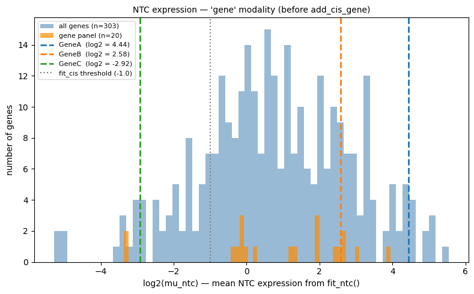

```python
def plot_ntc_log2_mu(model, gene_panel=None, highlight_genes=None,
                      modality_name='gene', n_bins=60, threshold=-1.0,
                      figsize=(8, 5)):
    """Histogram of log2(mu_ntc) for all features in `modality_name`,
    with an optional overlay histogram for `gene_panel` and vertical
    highlight lines for `highlight_genes`. Requires fit_ntc() to have
    already been run on this modality."""
    mod = model.get_modality(modality_name)
    ps = mod.posterior_samples_ntc
    if ps is None or 'mu_ntc' not in ps:
        raise ValueError(f"Run fit_ntc() on modality '{modality_name}' first.")

    mu_ntc = ps['mu_ntc']
    if isinstance(mu_ntc, torch.Tensor):
        mu_ntc = mu_ntc.mean(dim=0).detach().cpu().numpy().flatten()
    else:
        mu_ntc = np.asarray(mu_ntc).mean(axis=0).flatten()

    feature_names = mod.feature_names
    log2_mu = np.log2(mu_ntc)
    name_to_log2 = dict(zip(feature_names, log2_mu))

    fig, ax = plt.subplots(figsize=figsize)

    finite = np.isfinite(log2_mu)
    ax.hist(log2_mu[finite], bins=n_bins, color='steelblue', alpha=0.55,
            edgecolor='none', label=f'all genes (n={int(finite.sum())})')

    if gene_panel:
        panel_vals = np.array([
            name_to_log2[g] for g in gene_panel
            if g in name_to_log2 and np.isfinite(name_to_log2[g])
        ])
        ax.hist(panel_vals, bins=n_bins, color='darkorange', alpha=0.7,
                edgecolor='none', label=f'gene panel (n={len(panel_vals)})')

    colors = plt.cm.tab10.colors
    if highlight_genes:
        for i, g in enumerate(highlight_genes):
            if g not in name_to_log2:
                print(f"[WARN] '{g}' not found in modality '{modality_name}' feature_names — skipping")
                continue
            val = name_to_log2[g]
            ax.axvline(val, color=colors[i % len(colors)], lw=2, ls='--',
                        label=f'{g}  (log2 = {val:.2f})')

    ax.axvline(threshold, color='grey', lw=1.5, ls=':',
               label=f'fit_cis threshold ({threshold})')

    ax.set_xlabel('log2(mu_ntc) — mean NTC expression from fit_ntc()', fontsize=10)
    ax.set_ylabel('number of genes', fontsize=10)
    ax.set_title(f"NTC expression — '{modality_name}' modality (before add_cis_gene)", fontsize=10)
    ax.legend(fontsize=8)
    fig.tight_layout()
    return fig


fig = plot_ntc_log2_mu(
    model,
    gene_panel=GENE_PANEL,
    highlight_genes=HIGHLIGHT_GENES,
)
plt.show()
```

`GeneC` should land left of the grey threshold line — this is exactly the check `fit_cis()` performs automatically for whichever gene you commit to via `add_cis_gene()`; seeing it here first means you can rule it out (or pass `force=True` to `fit_cis()` deliberately) before spending compute on a cis fit that will fail its own sanity check.

## Next steps (not covered in this vignette)

With `fit_ntc()` done once across the whole transcriptome, you can now fork off a separate model per candidate cis gene without refitting NTC each time:

```
import copy
for gene in ["GeneA", "GeneB"]:            # skip GeneC — too lowly expressed
    m = copy.deepcopy(model)
    m.add_cis_gene(gene)                    # extracts the 'cis' modality
    m.fit_cis(sum_factor_col="sum_factor_adj")
    m.fit_trans(sum_factor_col="sum_factor_adj", function_type="additive_hill")
```

See the "Deferred Cis-Gene Workflow (`add_cis_gene`)" section of `CLAUDE.md` for the full details of what `add_cis_gene()` does internally.